# R avanzado. Sesión 2: Series de tiempo

Autor/a

Afiliación

Jorge de la Vega

ITAM

Fecha de publicación

9 de octubre de 2025

En esta sesión consideraremos ejemplos de series de tiempo, sus características y estimaciones desde el punto de vista de su aplicación práctica, usando `R`.

Dada la extensión del tema, no es posible abarcar todos los temas posibles, por lo que revisaremos algunos temas en especial.

En términos prácticos, una serie de tiempo se puede analizar con varios propósitos en mente: suavizamiento, modelación, predicción. Nos interesa comprender el comportamiento de una variable $y_t$ a lo largo del tiempo, por ejemplo, para:

- comprender sus fluctuaciones con respecto a un valor promedio, (variabilidad de la serie);
- identificar tendencia y nivel de la serie;
- proyectar su posible comportamiento hacia el futuro, generando pronósticos y predicciones útiles para la planeación y toma de decisiones;
- encontrar un modelo matemático que explique el *proceso generador de los datos* así como su *comportamiento*, a través de si misma o de otros posibles *predictores*.

Un supuesto fundamental de las series de tiempo es que es factible que *el comportamiento pasado de una variable nos ayude a explicar su comportamiento actual o su comportamiento futuro*.

# Pronósticos y análisis de series temporales.

Es importante hacer notar que pronosticar y analizar una serie de tiempo son dos actividades distintas. Un pronóstico es una visión de un futuro incierto, mientras que analizar una serie de tiempo es describir el proceso generador de los datos. Podemos analizar una serie de tiempo sin considerar como objetivo hacer pronósticos, así como podemos hacer pronósticos sin pensar en series de tiempo (o de hecho cualquier otro tipo de análisis).

Desde el punto de vista estadístico, los principales precursores de la actividad de pronóstico son la construcción de un modelo adecuado basado en el desarrollo histórico de la serie y la utilización de información relevante al posible desarrollo futuro de la serie.

## Ejemplos de series de tiempo

### 1. Datos de Covid-19

Los siguientes datos son tomados directamente del [micrositio de la Organización Mundial de la Salud](https://covid19.who.int/info?openIndex=2) en donde se puede encontrar el catálogo de variables disponibles. Nos concentraremos en los datos correspondiente a México.

Consideremos los datos diarios correspondientes a nuevos casos. La ventaja de tomar los datos directamente de la fuente es que se actualizarán oportunamente.

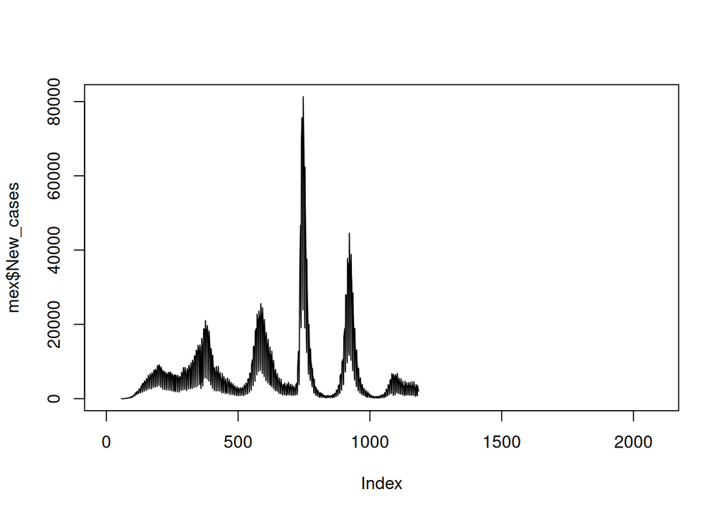

```r
library(readr)
library(lubridate)
datos <- read_csv("https://srhdpeuwpubsa.blob.core.windows.net/whdh/COVID/WHO-COVID-19-global-daily-data.csv")
mex <- subset(datos, Country == "Mexico")
plot(mex$New_cases, type = "l") # primer intento
```

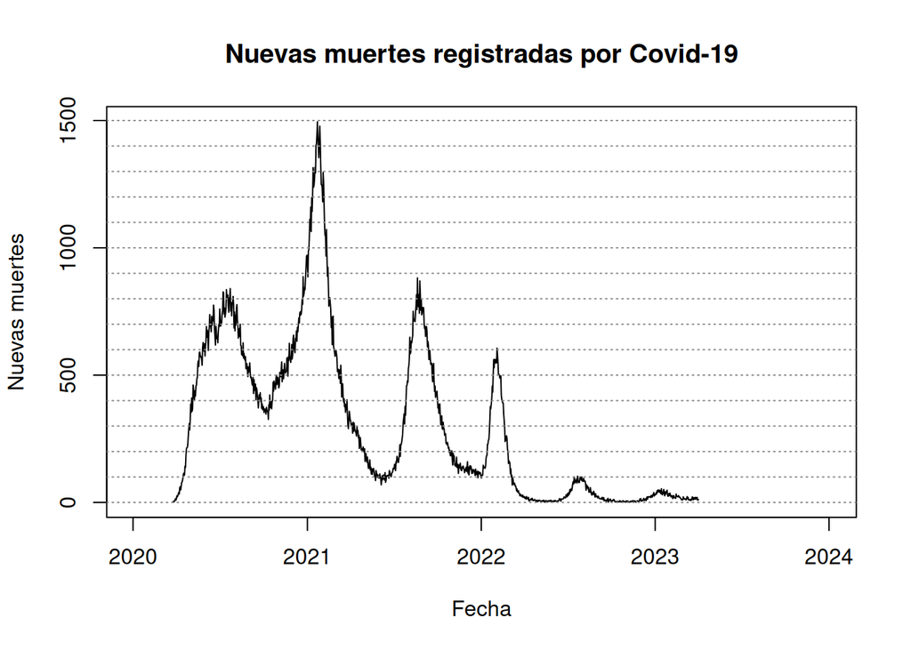

```r
mex$Fecha <- as.Date(mex$Date_reported, format = "%Y-%m-%d")
mex <- subset(mex, year(mex$Date_reported) < 2024)
plot(mex$Fecha, mex$New_deaths,
     type = "l",
     main = "Nuevas muertes registradas por Covid-19",
     xlab = "Fecha",
     ylab = "Nuevas muertes")
abline(h = seq(0, 1500, by = 100), lty = 3, col = "snow4")
```

### 2. Datos de Indice de Precios al Consumidor e inflación

Para obtener datos del [Sistema de información Económica (SIE)](https://www.banxico.org.mx/SieAPIRest/service/v1/doc/ejemplos) del Banco de México, podemos usar su API y el paquete `siebanxicor`.

```r
#install.packages("siebanxicor")
library(siebanxicor)
```

Se necesita generar un token para poder acceder a los datos. Se puede obtener un token desde este [enlace](https://www.banxico.org.mx/SieAPIRest/service/v1/token)

```r
setToken(token_jvg)
```

Podemos traer una serie o varias series al mismo tiempo. Por ejemplo,

```r
reserva <- getSeriesData("SF43707")
str(reserva)
```

```
List of 1
 $ SF43707:List of 2
  ..$ date : Date[1:1554], format: "1995-12-29" "1996-01-05" "1996-01-12" "1996-01-19" ...
  ..$ value: num [1:1554] 15741 15672 16045 15992 16002 ...
```

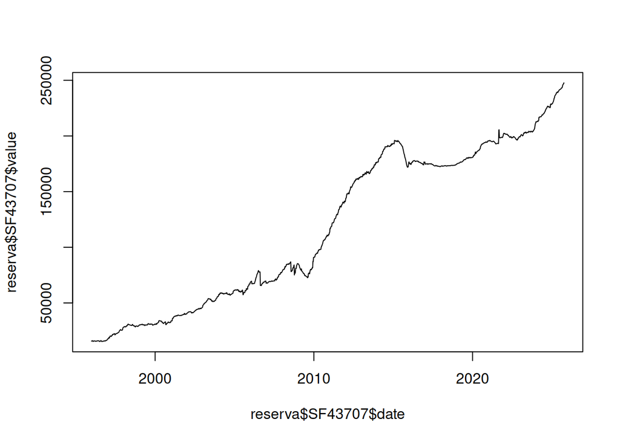

```r
plot(reserva$SF43707$date, reserva$SF43707$value, type = "l")
```

```r
# Obtener token de: https://www.banxico.org.mx/SieAPIRest/service/v1/token
setToken(token_jvg)
idSeries <- c("SP1")
inpc <- getSeriesData(idSeries)
str(inpc)
```

```
List of 1
 $ SP1:List of 2
  ..$ date : Date[1:681], format: "1969-01-01" "1969-02-01" "1969-03-01" "1969-04-01" ...
  ..$ value: num [1:681] 0.0116 0.0116 0.0116 0.0117 0.0117 ...
```

```r
head(inpc$SP1$value)
```

```
[1] 0.011595 0.011636 0.011648 0.011680 0.011680 0.011721
```

```r
head(inpc$SP1$date)
```

```
[1] "1969-01-01" "1969-02-01" "1969-03-01" "1969-04-01" "1969-05-01" "1969-06-01"
```

Para datos que son series de tiempo regulares, podemos convertirlas a objetos que son series de tiempo, lo que permite realizar algunas operaciones básicas sobre ellas que son más convenientes.

```r
inpc <- ts(inpc$SP1$value, start = c(1969,01), freq = 12)
head(inpc)
```

```
          Jan      Feb      Mar      Apr      May      Jun
1969 0.011595 0.011636 0.011648 0.011680 0.011680 0.011721
```

```r
tail(inpc)
```

```
         Apr     May     Jun     Jul     Aug     Sep
2025 139.620 140.012 140.405 140.780 140.867 141.197
```

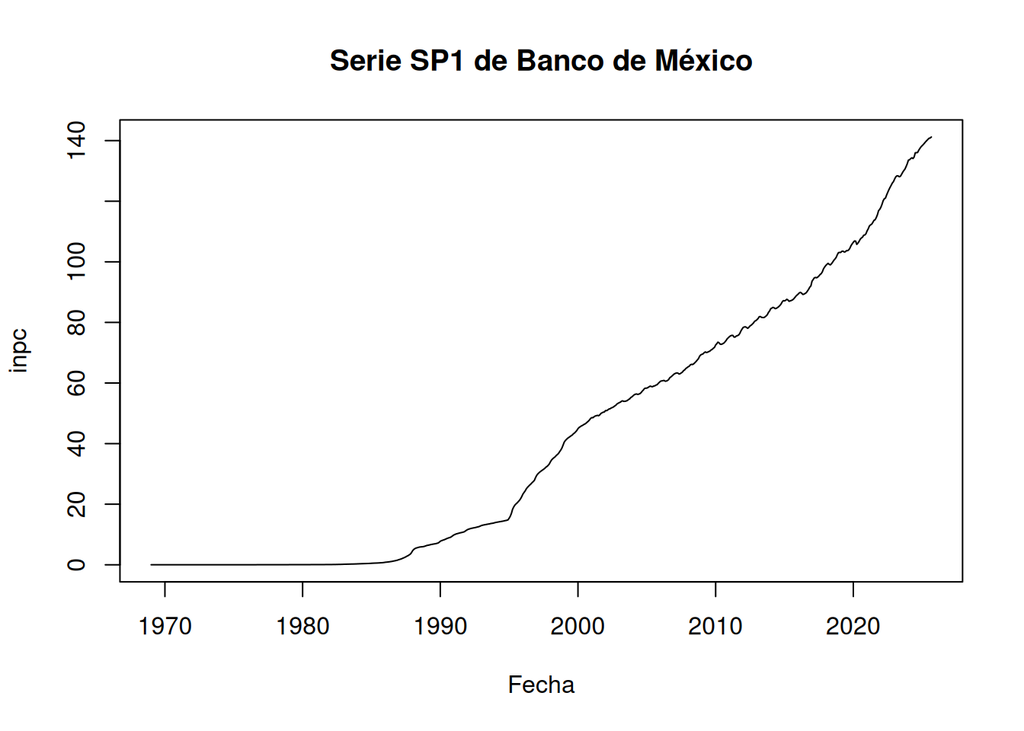

```r
plot(inpc, xlab = "Fecha", main = "Serie SP1 de Banco de México")
```

Con esta serie, podemos calcular la inflación mensual. Para esto podemos usar la siguiente función en las series de tiempo:

- `diff(y,lag = k)`: calcula las diferencias entre observaciones separadas $k$ valores: $w_{t} = y_t-y_{t-k}$

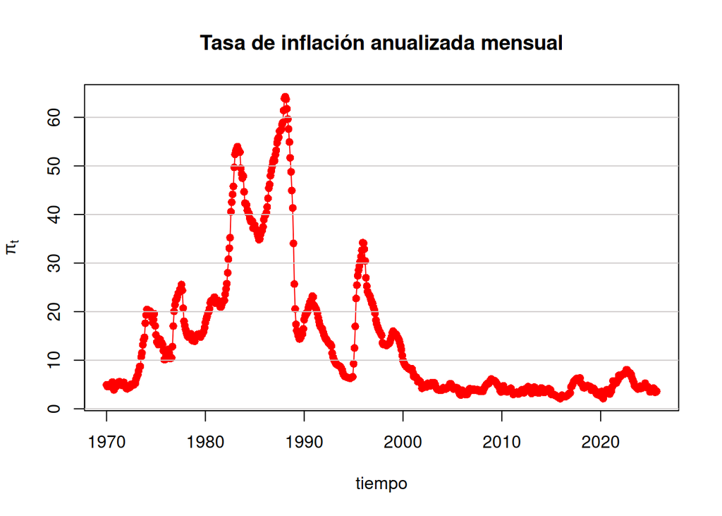

```r
inflacion <- 100*diff(inpc,12)/inpc # calcula la inflación
plot(inflacion, main = "Tasa de inflación anualizada mensual",
     xlab = "tiempo", ylab = expression(pi[t]),
     type = "o", pch =16, col = "red")
abline(h=seq(0,70,by=10),col = "snow3")
```

### 3. Goles de México en mundiales (a favor y en contra)

Los siguientes datos son tomados de Wikipedia. Notemos que esta serie es irregular, porque los datos no están igualmente espaciados.

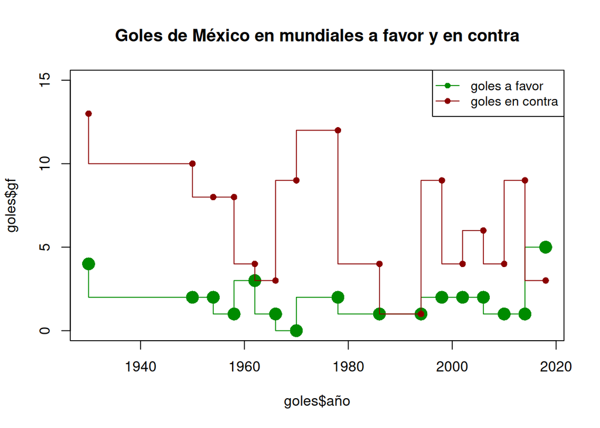

```r
goles <- data.frame(año = c(1930,1950,1954,1958,1962,1966,1970,1978,1986,1994,1998,2002,2006,2010,2014,2018),
                    gf = c(4,2,2,1,3,1,0,2,1,1,2,2,2,1,1,5),
                    gc = c(13,10,8,8,4,3,9,12,4,1,9,4,6,4,9,3))
plot(goles$año, goles$gf, ylim = c(0,15), col = "green4",
     main = "Goles de México en mundiales a favor y en contra", type = "S")
points(goles$año,goles$gf, pch = 16, col = "green4", cex = 2)
lines(goles$año,goles$gc, col = "red4",
     main = "Goles de México en mundiales a favor y en contra",
     type = "S")
points(goles$año, goles$gc, pch = 16, col = "red4", cex = 1)
legend("topright",legend=c("goles a favor", "goles en contra"),lty=c(1,1),col = c("green4","red4"),pch = c(16,16), cex = c(.9,.9))
```

Usualmente las series de tiempo irregulares son difíciles de manejar, pero se pueden trabajar con el paquete `zoo` en `R`. Esto corresponde a un curso más avanzado.

## Descomposición de series de tiempo.

Una forma de modelar una serie de tiempo se obtiene al suponer que está conformada de diferentes componentes. Los componentes básicos son los siguientes:

- **Tendencia**: el movimiento hacia arriba o hacia abajo que caracteriza a una serie de tiempo en un periodo de tiempo dado. Muestra el crecimiento o decline de una serie en el largo plazo.
- **Estacionalidad**: es el comportamiento que muestra una serie a lo largo de un periodo de tiempo, típicamente un año, y que se repite durante varios periodos.
- **Ciclo**: se refiere a movimientos recurrentes hacia arriba o hacia abajo alrededor del nivel de tendencia. Usualmente son movimientos que se observan en periodos mayores a un año.
- **Error**: se refiere a la parte de la serie que es completamente aleatoria; es el error estadístico que se presenta por incertidumbre.

El método clásico de descomposición tiene el objetivo de separar los componentes de una serie de tiempo. Este método supone que una serie de tiempo se puede escribir como una función de tres componentes:

$$X_t= f(TC_t,S_t,E_t)$$

donde $f$ es una función que relaciona los componentes, $TC$ es un componente de tendencia-ciclo, $S$ es un componente estacional, $E$ es el componente de error o ruido de la serie.

```r
pasajeros <- ts(c(2295, 2068, 2428, 2330, 2378, 2413, 2869, 2666, 2311, 2494, 2519, 2721,
               2472, 2113, 2494, 2432, 2551, 2622, 3108, 2884, 2510, 2672, 2727, 2950,
               2719, 2333, 2669, 2732, 2853, 2777, 3256, 3149, 2683, 2946, 2967, 3171,
               2894, 2569, 3117, 3080, 3218, 3199, 3711, 3532, 3010, 3265, 3310, 3528,
               3189, 2860, 3357, 3188, 3420, 3477, 4034, 3771, 3310, 3546, 3619, 3937,
               3614, 3132, 3620, 3705, 3762, 3805, 4211, 4004, 3347, 3717, 3809, 4004,
               3830, 3362, 3918, 3880, 3962, 3918, 4449, 4226, 3755, 4060, 4085, 4255,
               3954, 3516, 4123, 4127, 4347, 4261, 4629, 4432, 3914, 4250, 4252, 4503,
               4211, 3824, 2668,  296,  276,  559, 1032, 1350, 1508, 1853, 2045, 2360,
               2076, 1616, 2354, 2626, 3033, 3135, 3593, 3354, 2992, 3508, 3710, 4059,
               3249, 3008, 3829, 4007, 3589, 3500, 4345, 4317, 3868, 4181, 4120, 4245,
               3997, 3562, 4130, 4002, 3928, 3921, 4329, 4309, 3829, 4042, 4109, 4259,
               3795, 3489, 3781, 3692, 3847, 3717, 4118, 3999, 3595, 3716, 3708, 3901,
               3715, 3247, 3701, 3683, 3610, 4019, 3936), start = c(2012,01), freq = 12)
```

La caida se dede al efecto de la pandemia. Para el ejercicio que haremos aquí, consideraremos el comportamiento de la serie sin la caída mostrada para poder entender el comportamiento “normal” de la serie, y luego veremos cómo podemos modelar esta caída.

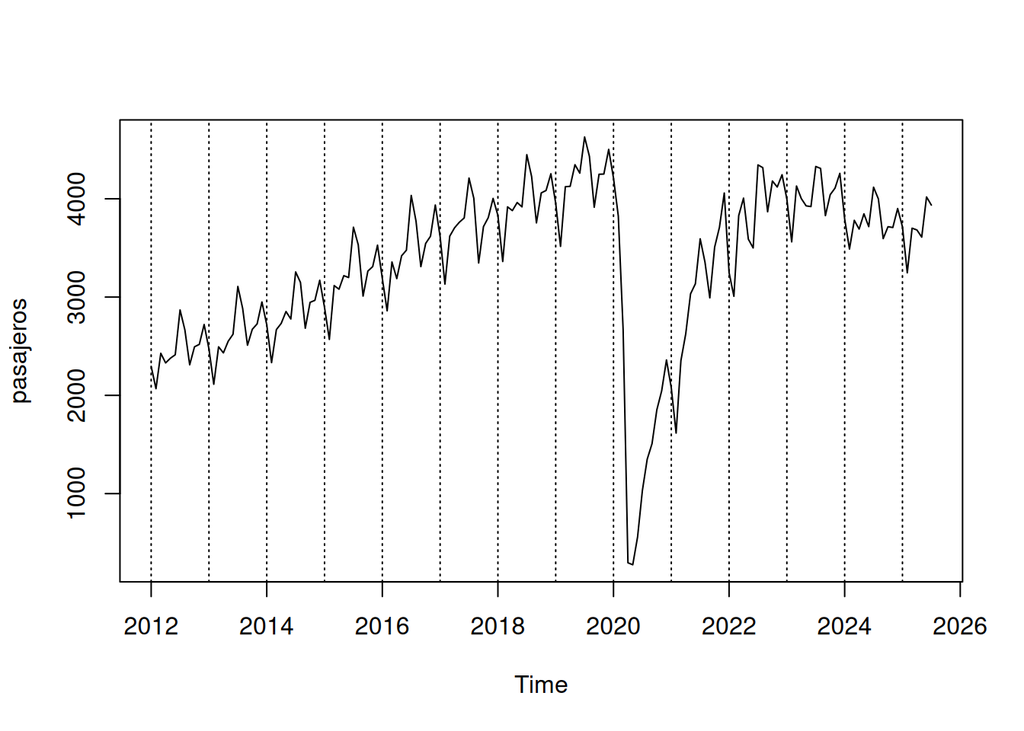

```r
plot(pasajeros)
abline(v = 2012:2025, lty = 3)
```

A través de hacer varios promedios se van teniendo los diferentes componentes de la serie. Aquí lo haremos directo con una sóla función:

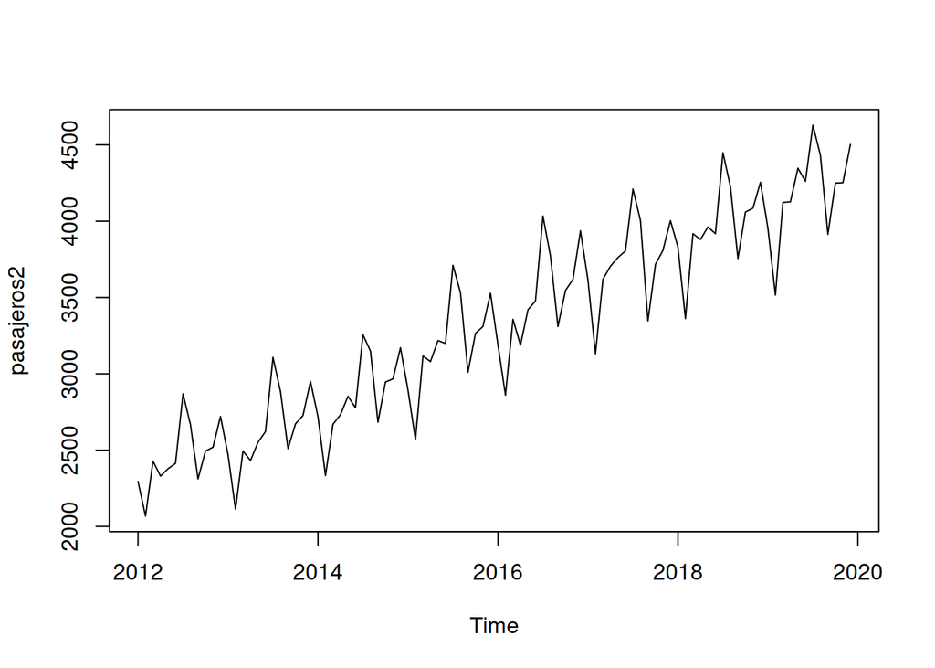

```r
pasajeros2 <- window(pasajeros, end = c(2019,12))
plot(pasajeros2)
```

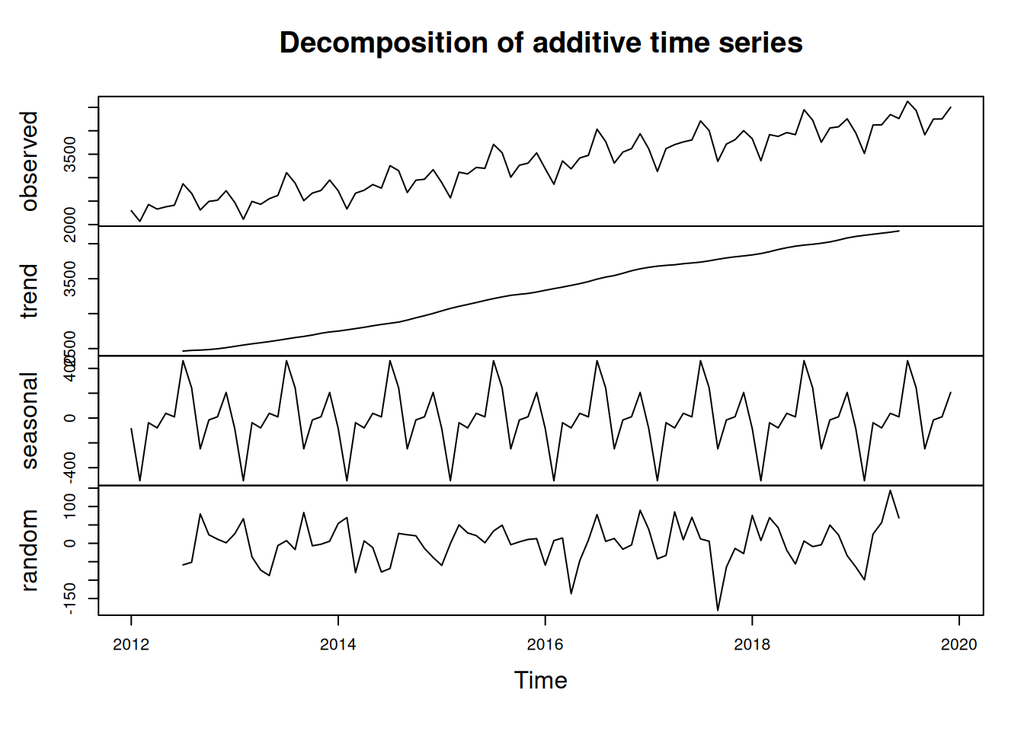

```r
m <- decompose(pasajeros2, type = "a")
plot(m)
```

```r
m
```

```
$x
      Jan  Feb  Mar  Apr  May  Jun  Jul  Aug  Sep  Oct  Nov  Dec
2012 2295 2068 2428 2330 2378 2413 2869 2666 2311 2494 2519 2721
2013 2472 2113 2494 2432 2551 2622 3108 2884 2510 2672 2727 2950
2014 2719 2333 2669 2732 2853 2777 3256 3149 2683 2946 2967 3171
2015 2894 2569 3117 3080 3218 3199 3711 3532 3010 3265 3310 3528
2016 3189 2860 3357 3188 3420 3477 4034 3771 3310 3546 3619 3937
2017 3614 3132 3620 3705 3762 3805 4211 4004 3347 3717 3809 4004
2018 3830 3362 3918 3880 3962 3918 4449 4226 3755 4060 4085 4255
2019 3954 3516 4123 4127 4347 4261 4629 4432 3914 4250 4252 4503

$seasonal
             Jan         Feb         Mar         Apr         May         Jun         Jul         Aug         Sep
2012  -85.768849 -504.899802  -37.381944  -79.375992   38.284722    9.647817  462.546627  243.195437 -247.798611
2013  -85.768849 -504.899802  -37.381944  -79.375992   38.284722    9.647817  462.546627  243.195437 -247.798611
```

[output cut: 56 more lines]

La ventaja de tener identificados los componentes de la serie es que ahora podemos pronosticar cada componente por separado.

## Promedios móviles

Un *promedio móvil simple de orden* $k$ para el tiempo $t$ se define como el promedio de las $k$ observaciones anteriores a $t$:
$$F_t^{(k)} = \frac{y_{t-1} + y_{t-2} + \cdots + y_{t-k}}{k} = \frac{1}{k}\sum_{i=1}^ky_{t-i}$$

Un promedio móvil de orden $k$ se denota como $MA(k)$. Mientras más grande es $k$ el efecto de suavizamiento es mayor, y se pierden más observaciones.

```r
library(forecast) # Rob Hyndman https://otexts.com/fpp3
```

```r
# Vamos a calcular el ajuste
plot(pasajeros2)
(ma5 <- ma(pasajeros2, order = 5, centre = T))
```

```
        Jan    Feb    Mar    Apr    May    Jun    Jul    Aug    Sep    Oct    Nov    Dec
2012     NA     NA 2299.8 2323.4 2483.6 2531.2 2527.4 2550.6 2571.8 2542.2 2503.4 2463.8
2013 2463.8 2446.4 2412.4 2442.4 2641.4 2719.4 2735.0 2759.2 2780.2 2748.6 2715.6 2680.2
2014 2679.6 2680.6 2661.2 2672.8 2857.4 2953.4 2943.6 2962.2 3000.2 2983.2 2932.2 2909.4
2015 2943.6 2966.2 2975.6 3036.6 3265.0 3348.0 3334.0 3343.4 3365.6 3329.0 3260.4 3230.4
2016 3248.8 3224.4 3202.8 3260.4 3495.2 3578.0 3602.4 3627.6 3656.0 3636.6 3605.2 3569.6
2017 3584.4 3601.6 3566.6 3604.8 3820.6 3897.4 3825.8 3816.8 3817.6 3776.2 3741.4 3744.4
2018 3784.6 3798.8 3790.4 3808.0 4025.4 4087.0 4062.0 4081.6 4115.0 4076.2 4021.8 3974.0
2019 3986.6 3995.0 4013.4 4074.8 4297.4 4359.2 4316.6 4297.2 4295.4 4270.2     NA     NA
```

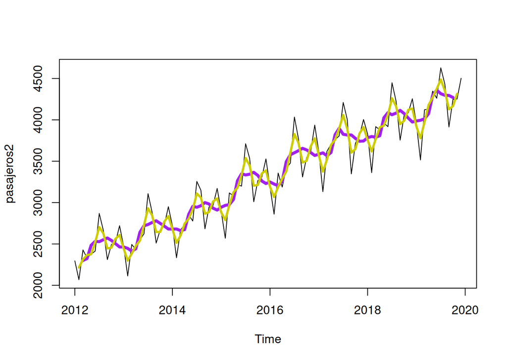

```r
lines(ma5, col = "purple", lwd = 4)
lines(ma(pasajeros2, order = 2), col = "yellow3", lwd = 3)
```

```r
# Para hacer un pronóstico, de un horizonte de 60 periodos
(F5 <- forecast(ma5, h = 60, level = c(0.80, 0.95, 0.99))) # h es el horizonte
```

```
         Point Forecast    Lo 80    Hi 80    Lo 95    Hi 95    Lo 99    Hi 99
Nov 2019       4206.231 4173.423 4239.039 4156.056 4256.406 4140.290 4272.173
Dec 2019       4160.963 4115.177 4206.748 4090.940 4230.986 4068.937 4252.988
Jan 2020       4172.338 4116.243 4228.432 4086.549 4258.127 4059.592 4285.084
Feb 2020       4163.939 4099.449 4228.429 4065.310 4262.567 4034.319 4293.559
Mar 2020       4140.079 4068.558 4211.600 4030.697 4249.461 3996.326 4283.832
Apr 2020       4180.995 4102.056 4259.934 4060.268 4301.722 4022.333 4339.657
May 2020       4455.228 4364.580 4545.876 4316.594 4593.862 4273.032 4637.424
Jun 2020       4550.149 4451.403 4648.896 4399.130 4701.169 4351.676 4748.623
Jul 2020       4527.819 4423.832 4631.807 4368.784 4686.855 4318.811 4736.827
Aug 2020       4544.192 4434.429 4653.955 4376.324 4712.060 4323.576 4764.808
Sep 2020       4570.312 4454.787 4685.838 4393.631 4746.994 4338.114 4802.511
Oct 2020       4525.471 4406.255 4644.687 4343.146 4707.796 4285.855 4765.087
Nov 2020       4456.432 4334.506 4578.358 4269.963 4642.901 4211.370 4701.494
Dec 2020       4407.250 4282.389 4532.111 4216.291 4598.209 4156.288 4658.212
Jan 2021       4418.086 4288.803 4547.370 4220.364 4615.808 4158.236 4677.937
Feb 2021       4407.995 4275.060 4540.929 4204.689 4611.301 4140.805 4675.184
Mar 2021       4381.557 4245.640 4517.474 4173.690 4589.423 4108.374 4654.740
Apr 2021       4423.680 4282.774 4564.586 4208.183 4639.177 4140.469 4706.891
May 2021       4712.586 4558.685 4866.487 4477.214 4947.957 4403.255 5021.916
Jun 2021       4811.731 4650.842 4972.620 4565.673 5057.789 4488.356 5135.106
Jul 2021       4786.876 4623.201 4950.551 4536.557 5037.195 4457.901 5115.851
Aug 2021       4802.952 4635.204 4970.700 4546.403 5059.500 4465.790 5140.114
Sep 2021       4829.331 4657.218 5001.443 4566.107 5092.555 4483.396 5175.266
Oct 2021       4780.742 4607.044 4954.440 4515.094 5046.391 4431.621 5129.863
Nov 2021       4706.633 4532.446 4880.819 4440.237 4973.028 4356.530 5056.736
Dec 2021       4653.537 4478.251 4828.824 4385.459 4921.615 4301.223 5005.852
Jan 2022       4663.835 4485.163 4842.506 4390.580 4937.090 4304.717 5022.952
Feb 2022       4652.051 4470.911 4833.190 4375.022 4929.079 4287.973 5016.128
Mar 2022       4623.035 4440.191 4805.878 4343.400 4902.670 4255.532 4990.538
Apr 2022       4666.365 4479.010 4853.719 4379.831 4952.898 4289.795 5042.934
May 2022       4969.944 4767.486 5172.401 4660.312 5279.576 4563.018 5376.869
Jun 2022       5073.313 4863.732 5282.894 4752.787 5393.839 4652.070 5494.556
Jul 2022       5045.933 4834.646 5257.220 4722.797 5369.069 4621.261 5470.606
Aug 2022       5061.712 4846.974 5276.449 4733.299 5390.124 4630.105 5493.319
Sep 2022       5088.349 4869.732 5306.965 4754.003 5422.694 4648.944 5527.753
Oct 2022       5036.013 4816.976 5255.051 4701.025 5371.002 4595.763 5476.264
Nov 2022       4956.834 4738.661 5175.006 4623.167 5290.500 4518.322 5395.346
Dec 2022       4899.825 4681.659 5117.991 4566.168 5233.481 4461.326 5338.323
Jan 2023       4909.583 4688.519 5130.647 4571.495 5247.671 4465.261 5353.906
Feb 2023       4896.106 4673.236 5118.977 4555.255 5236.957 4448.152 5344.060
Mar 2023       4864.513 4640.723 5088.302 4522.256 5206.769 4414.712 5314.314
Apr 2023       4909.049 4680.872 5137.227 4560.082 5258.017 4450.428 5367.670
May 2023       5227.301 4981.881 5472.722 4851.963 5602.640 4734.023 5720.579
Jun 2023       5334.895 5081.962 5587.827 4948.068 5721.722 4826.518 5843.271
Jul 2023       5304.990 5051.067 5558.913 4916.648 5693.332 4794.622 5815.358
Aug 2023       5320.472 5063.429 5577.514 4927.359 5713.584 4803.834 5837.109
Sep 2023       5347.367 5086.671 5608.063 4948.667 5746.067 4823.386 5871.348
Oct 2023       5291.285 5031.028 5551.542 4893.256 5689.313 4768.186 5814.383
Nov 2023       5207.035 4948.695 5465.374 4811.939 5602.130 4687.791 5726.278
Dec 2023       5146.112 4888.627 5403.597 4752.323 5539.901 4628.586 5663.638
Jan 2024       5155.332 4895.244 5415.419 4757.562 5553.101 4632.574 5678.089
Feb 2024       5140.162 4878.734 5401.590 4740.343 5539.982 4614.710 5665.614
Mar 2024       5105.991 4844.237 5367.744 4705.674 5506.308 4579.885 5632.097
Apr 2024       5151.734 4885.582 5417.886 4744.690 5558.779 4616.787 5686.682
May 2024       5484.659 5199.149 5770.169 5048.009 5921.309 4910.804 6058.514
Jun 2024       5596.476 5302.972 5889.981 5147.600 6045.352 5006.553 6186.400
Jul 2024       5564.047 5270.110 5857.984 5114.509 6013.585 4973.254 6154.840
Aug 2024       5579.232 5282.380 5876.083 5125.236 6033.227 4982.581 6175.883
Sep 2024       5606.385 5305.992 5906.778 5146.974 6065.797 5002.616 6210.154
Oct 2024       5546.556 5247.320 5845.792 5088.914 6004.198 4945.112 6148.000
```

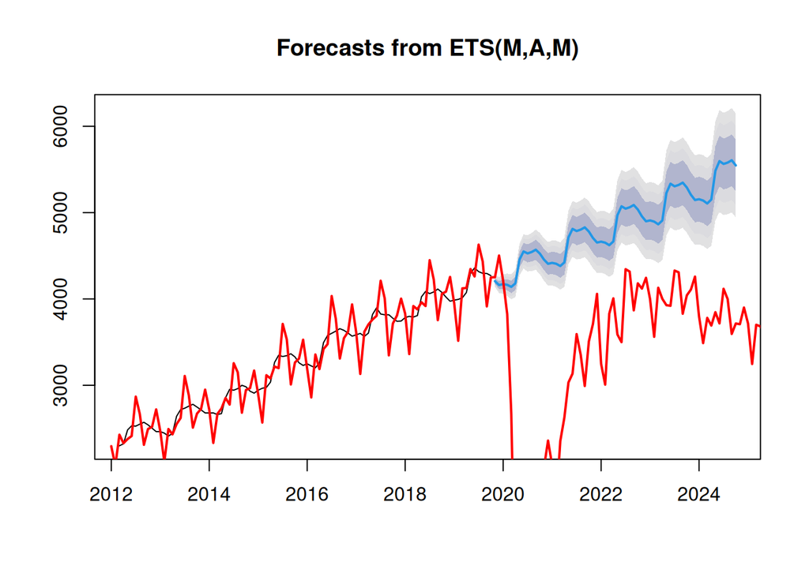

```r
plot(F5)
lines(pasajeros, col = "red", lwd = 2)
```

## Suavizamiento exponencial

Hay situaciones en donde las observaciones más recientes contienen información más actualizada sobre lo que se espera en el futuro y por lo tanto, se les tiene que dar un peso mayor que a las observaciones más antiguas. El método de suavizamiento exponencial calcula el pronóstico como una combinación entre el pronóstico del periodo anterior y la última observación disponible: $F_t(\alpha) = \alpha y_{t-1} + (1-\alpha)F_{t-1}$ donde al parámetro $\alpha$ se le llama factor de suavizamiento, y $\alpha\in (0,1)$ es un peso que pondera la relación entre ambos términos.

```r
(se1 <- ses(pasajeros2, alpha = NULL, h = 60, level = c(0.80,0.95,0.99)))
```

```
         Point Forecast    Lo 80    Hi 80    Lo 95    Hi 95    Lo 99    Hi 99
Jan 2020       4312.636 3962.608 4662.664 3777.315 4847.957 3609.104 5016.167
Feb 2020       4312.636 3947.323 4677.949 3753.937 4871.334 3578.382 5046.890
Mar 2020       4312.636 3932.652 4692.620 3731.500 4893.772 3548.894 5076.378
Apr 2020       4312.636 3918.526 4706.746 3709.897 4915.375 3520.503 5104.769
May 2020       4312.636 3904.890 4720.382 3689.042 4936.230 3493.095 5132.177
Jun 2020       4312.636 3891.695 4733.577 3668.863 4956.409 3466.574 5158.698
Jul 2020       4312.636 3878.902 4746.370 3649.296 4975.975 3440.860 5184.412
Aug 2020       4312.636 3866.475 4758.797 3630.291 4994.981 3415.883 5209.389
Sep 2020       4312.636 3854.385 4770.887 3611.801 5013.471 3391.583 5233.689
Oct 2020       4312.636 3842.606 4782.666 3593.787 5031.485 3367.908 5257.364
Nov 2020       4312.636 3831.115 4794.157 3576.213 5049.059 3344.812 5280.460
Dec 2020       4312.636 3819.891 4805.380 3559.048 5066.224 3322.254 5303.018
Jan 2021       4312.636 3808.918 4816.354 3542.266 5083.006 3300.198 5325.073
Feb 2021       4312.636 3798.179 4827.093 3525.842 5099.430 3278.614 5346.658
Mar 2021       4312.636 3787.660 4837.612 3509.754 5115.518 3257.470 5367.802
Apr 2021       4312.636 3777.347 4847.925 3493.982 5131.290 3236.742 5388.530
May 2021       4312.636 3767.229 4858.043 3478.508 5146.764 3216.406 5408.866
Jun 2021       4312.636 3757.295 4867.977 3463.316 5161.956 3196.440 5428.832
Jul 2021       4312.636 3747.536 4877.735 3448.391 5176.881 3176.825 5448.447
Aug 2021       4312.636 3737.943 4887.329 3433.719 5191.553 3157.543 5467.728
Sep 2021       4312.636 3728.507 4896.764 3419.288 5205.983 3138.578 5486.694
Oct 2021       4312.636 3719.222 4906.050 3405.087 5220.185 3119.915 5505.357
Nov 2021       4312.636 3710.079 4915.193 3391.105 5234.167 3101.538 5523.733
Dec 2021       4312.636 3701.073 4924.199 3377.331 5247.941 3083.437 5541.835
Jan 2022       4312.636 3692.198 4933.074 3363.758 5261.514 3065.598 5559.673
Feb 2022       4312.636 3683.448 4941.824 3350.376 5274.896 3048.011 5577.260
Mar 2022       4312.636 3674.818 4950.454 3337.177 5288.095 3030.666 5594.606
Apr 2022       4312.636 3666.303 4958.969 3324.155 5301.117 3013.551 5611.720
May 2022       4312.636 3657.899 4967.373 3311.302 5313.970 2996.660 5628.612
Jun 2022       4312.636 3649.601 4975.671 3298.612 5326.660 2979.982 5645.290
Jul 2022       4312.636 3641.406 4983.866 3286.078 5339.193 2963.511 5661.761
Aug 2022       4312.636 3633.310 4991.962 3273.696 5351.575 2947.238 5678.034
Sep 2022       4312.636 3625.309 4999.963 3261.460 5363.812 2931.157 5694.115
Oct 2022       4312.636 3617.400 5007.872 3249.365 5375.907 2915.261 5710.011
Nov 2022       4312.636 3609.581 5015.691 3237.405 5387.866 2899.544 5725.728
Dec 2022       4312.636 3601.847 5023.425 3225.578 5399.694 2883.999 5741.273
Jan 2023       4312.636 3594.196 5031.076 3213.877 5411.395 2868.622 5756.650
Feb 2023       4312.636 3586.626 5038.645 3202.300 5422.972 2853.407 5771.865
Mar 2023       4312.636 3579.135 5046.137 3190.842 5434.429 2838.349 5786.922
Apr 2023       4312.636 3571.719 5053.553 3179.501 5445.771 2823.444 5801.828
May 2023       4312.636 3564.376 5060.896 3168.271 5457.001 2808.686 5816.586
Jun 2023       4312.636 3557.105 5068.167 3157.151 5468.121 2794.071 5831.201
Jul 2023       4312.636 3549.903 5075.369 3146.137 5479.135 2779.596 5845.676
Aug 2023       4312.636 3542.768 5082.503 3135.225 5490.047 2765.256 5860.016
Sep 2023       4312.636 3535.699 5089.572 3124.414 5500.858 2751.048 5874.224
Oct 2023       4312.636 3528.694 5096.578 3113.701 5511.571 2736.968 5888.304
Nov 2023       4312.636 3521.751 5103.521 3103.082 5522.190 2723.012 5902.259
Dec 2023       4312.636 3514.868 5110.404 3092.556 5532.716 2709.179 5916.093
Jan 2024       4312.636 3508.044 5117.227 3082.119 5543.153 2695.463 5929.809
Feb 2024       4312.636 3501.278 5123.994 3071.771 5553.501 2681.863 5943.409
Mar 2024       4312.636 3494.567 5130.705 3061.508 5563.764 2668.375 5956.897
Apr 2024       4312.636 3487.911 5137.360 3051.329 5573.943 2654.997 5970.275
May 2024       4312.636 3481.309 5143.963 3041.231 5584.041 2641.726 5983.546
Jun 2024       4312.636 3474.758 5150.514 3031.212 5594.059 2628.560 5996.712
Jul 2024       4312.636 3468.258 5157.014 3021.272 5604.000 2615.496 6009.776
Aug 2024       4312.636 3461.808 5163.464 3011.407 5613.865 2602.531 6022.740
Sep 2024       4312.636 3455.406 5169.865 3001.617 5623.655 2589.665 6035.607
Oct 2024       4312.636 3449.052 5176.220 2991.899 5633.373 2576.893 6048.379
Nov 2024       4312.636 3442.745 5182.527 2982.252 5643.020 2564.215 6061.057
Dec 2024       4312.636 3436.482 5188.790 2972.674 5652.597 2551.628 6073.644
```

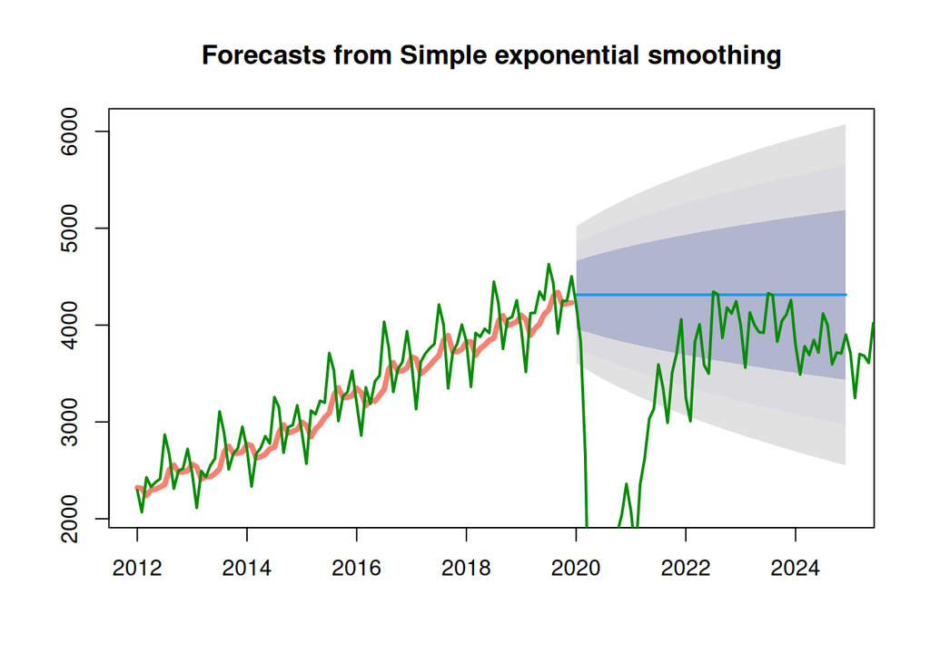

```r
plot(se1)
lines(se1$fitted, lwd = 4, col = "salmon")
lines(pasajeros, col = "green4", lwd = 2)
```

El pronóstico basado en el suavizamiento exponencial simple produce pronósticos planos, por lo que es sólo adecuado para series de tiempo que no tienen tendencia o componente estacional. En este ejemplo, es un mal método a aplicar.

## Holt-Winters

Este es uno de los modelos más utilizados de pronósticos. El método de Holt-Winters está diseñado para datos estacionales. Winters (1960) extendió el método de Holt, y hay dos versiones dependiendo de cómo se modele la estacionalidad (aditiva o multiplicativa). En este caso se tienen 4 ecuaciones y 3 parámetros:

- Nivel $L_t = \alpha \frac{y_t}{S_{t-s}} + (1-\alpha)(L_{t-1}+b_{t-1})$
- Tendencia $b_t = \beta (L_t-L_{t-1}) + (1-\beta)b_{t-1}$
- Estacional $S_t = \gamma \frac{y_t}{L_t} + (1-\gamma)S_{t-s}$
- Pronóstico $F_{t+m} = (L_t+b_t m)S_{t-s+m}$

```r
m <- HoltWinters(pasajeros2)
predict(m, n.ahead = 5)
```

```
          Jan      Feb      Mar      Apr      May
2020 4231.587 3808.798 4366.667 4332.433 4456.289
```

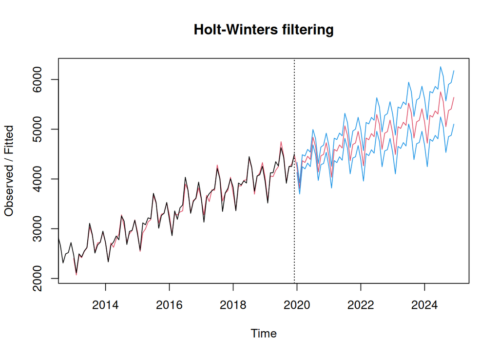

```r
plot(m, predicted.values = predict(m, 60, prediction.interval = T, level =.85))
```

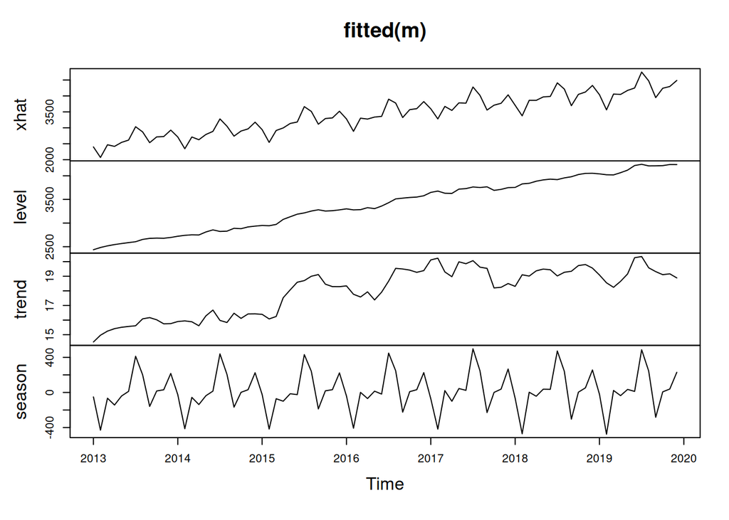

```r
plot(fitted(m)) # Los componentes de la serie estimada.
```

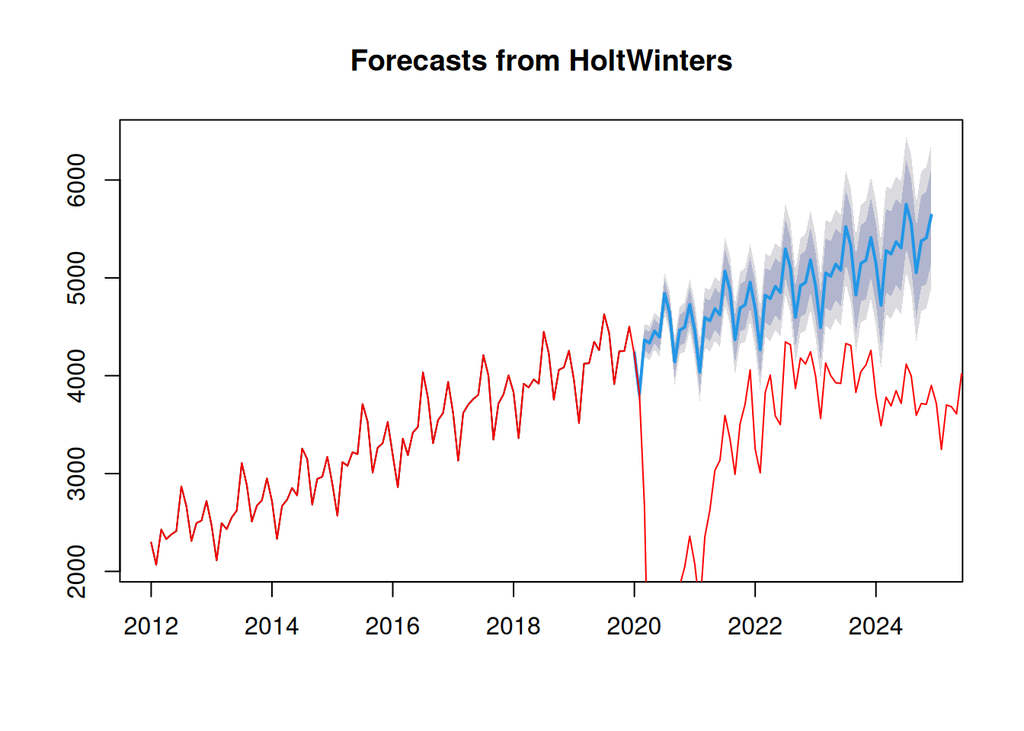

```r
# también podemos la función forcast sobre el modelo ajustado por Holt-Winters
plot(forecast(m, h = 60))
lines(pasajeros, col = "red")
```

## Box y Jenkins (ARIMA)

Aquí agrego un resumen de las herramientas que son necesarias para hacer un análisis de series de tiempo tipo Box-Jenkins. Algunas son necesarias para construir el modelo y otras son necesarias para diagnosticar el modelo.

- Gráficas de las series de tiempo.
- Concepto de estacionariedad, operador diferencia y prueba de estacionariedad de Dickey-Fuller.
- Conceptos de autocorrelación y autocorrelación parcial y sus respectivas funciones y gráficas (*acf,pacf*)
- Concepto y gráficas de ruido blanco.
- Pruebas estadísticas para coeficientes de autocorrelación de Bartlett, y de Ljung-Box.
- Definiciones de procesos: autoregresivo (AR), de promedios móviles (MA).

En lo que sigue, se dará un repaso muy general de estos conceptos, y veremos varios ejemplos para ir aplicando los conceptos.

### Ejemplo 1: Kleenex

Para conocer el margen de mercado que tiene Kimberly-Clark con la marca kleenex, se le han pedido su producción semanal, que reporta para las 120 semanas anteriores a esta y en unidades de 10,000 paquetes. Se requiere un modelo para analizar su comportamiento y hacer un pronóstico para saber si no está inundando el mercado.

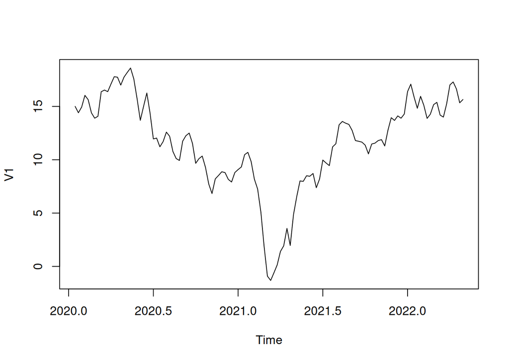

```r
kleenex <- read.table("https://raw.githubusercontent.com/jvega68/MIDE-MyE/refs/heads/main/Datos/kleenex.txt")
kleenex <- ts(kleenex, start = c(2020,3), freq = 52)
plot(kleenex)
```

Vemos que la serie no parece fluctuar en torno a una media constante, y por lo tanto no parece ser estacionaria. Si tomamos las primeras diferencias de la serie, definidas como $z_t = y_t - y_{t-1}$ utilizando el operador `diff` obtenemos lo siguiente:

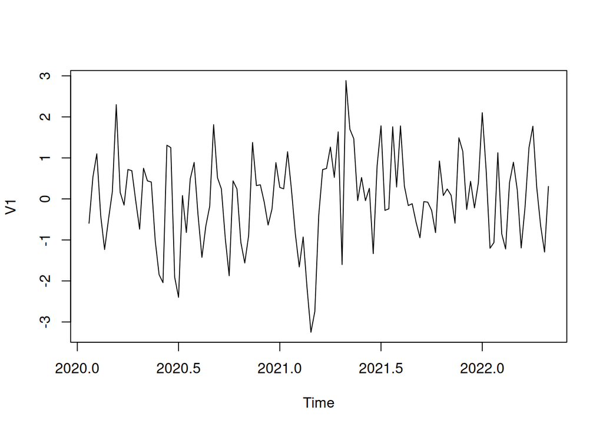

```r
dkleenex <- diff(kleenex, dif = 1)
plot(dkleenex)
```

Ahora la serie parece fluctuar alrededor de una media constante, por lo que la primera diferencia parece ser estacionaria.

En ocasiones no es suficiente tomar sólo una diferencia. Si la primera diferencia no resulta estacionaria, entonces debemos tomar una segunda diferencia. Por ejemplo, tomamos la segunda diferencia de estos datos:

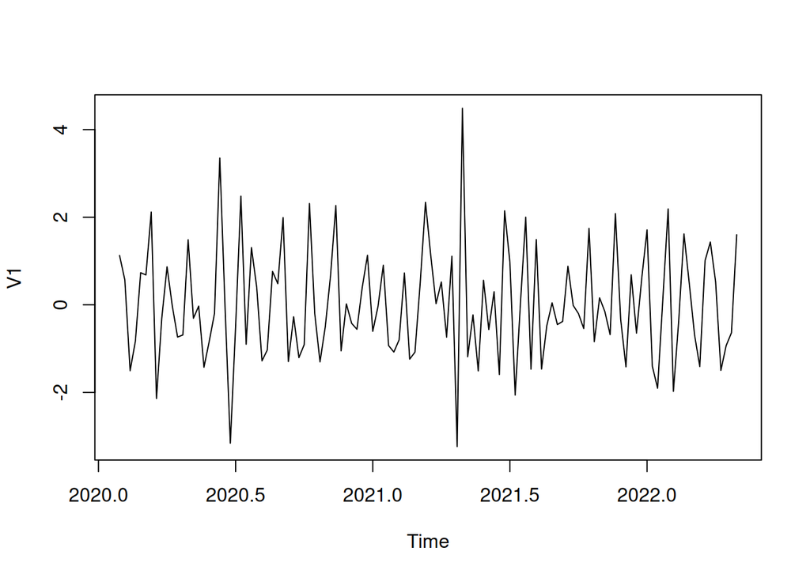

```r
d2kleenex <- diff(kleenex, dif = 2)
plot(d2kleenex)
```

Identificando estacionariedad con las funciones de autocorrelación:

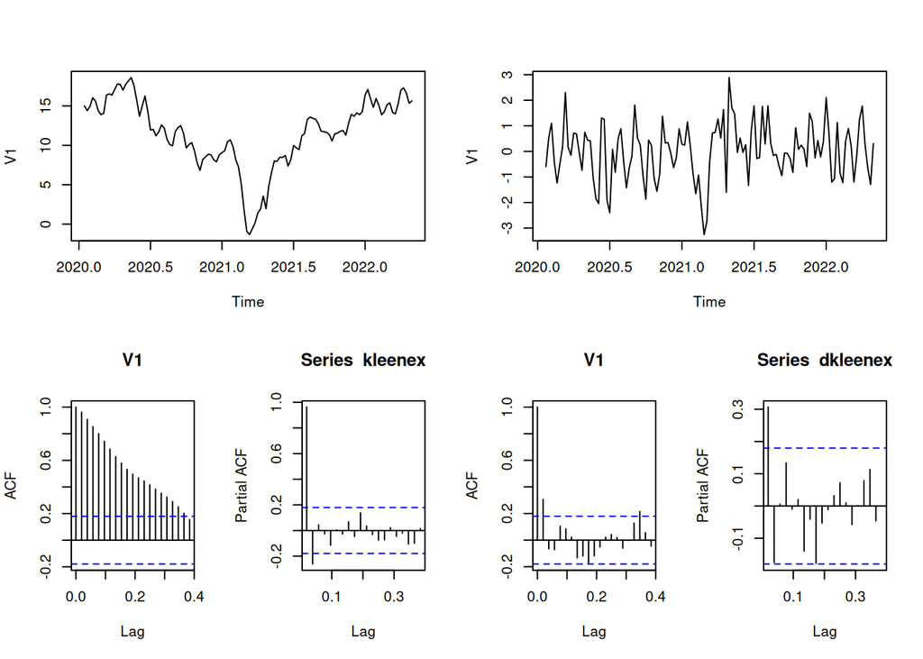

```r
layout(matrix(c(1,1,2,2,3,4,5,6),nrow = 2, byrow = T))
plot(kleenex)
plot(dkleenex)
acf(kleenex)
pacf(kleenex)
acf(dkleenex)
pacf(dkleenex)
```

Pruebas de Box (Box-Pierce y Ljung-Box):

```r
Box.test(dkleenex, lag = 1, type = "Box")
```

```
    Box-Pierce test

data:  dkleenex
X-squared = 11.189, df = 1, p-value = 0.000823
```

```r
Box.test(dkleenex, lag = 1, type = "Ljung")
```

```
    Box-Ljung test

data:  dkleenex
X-squared = 11.473, df = 1, p-value = 0.0007061
```

Cálculo de modelos ARIMA por fuerza bruta:

```r
AIC <- array(NA, dim =c(4,2,4),
             dimnames = list(paste("p = ",0:3),
                             paste("d = ",0:1),
                             paste("q = ",0:3)))
for(p in 1:4)
  for( q in 1:4)
    for(d in 1:2)
      AIC[p,d,q] <- arima(kleenex, order = c(p-1,d-1,q-1))$aic
AIC
```

```
, , q =  0

         d =  0   d =  1
p =  0 698.9005 362.2711
p =  1 369.6550 352.5789
p =  2 358.3822 350.7612
p =  3 357.5850 352.7582

, , q =  1

         d =  0   d =  1
p =  0 568.3708 349.9821
p =  1 356.3556 351.9658
p =  2 358.2153 352.7601
p =  3 359.5559 352.4818

, , q =  2

         d =  0   d =  1
p =  0 475.5712 351.9519
p =  1 358.1165 351.3134
p =  2 357.4390 353.5758
p =  3 359.2680 349.9126

, , q =  3

         d =  0   d =  1
p =  0 437.5709 351.8757
p =  1 358.6551 352.6993
p =  2 359.2192 353.2524
p =  3 360.9870 350.9945
```

```r
# Localiza el mínimo AIC
AIC[which.min(AIC)]
```

```
[1] 349.9126
```

Elegimos dos modelos relativamente cercanos, para ver los coeficientes

```r
mod1 <- arima(kleenex,order = c(3,1,2))
mod1
```

```
Call:
arima(x = kleenex, order = c(3, 1, 2))

Coefficients:
         ar1      ar2     ar3      ma1     ma2
      1.5308  -1.3686  0.3847  -1.2517  0.9587
s.e.  0.0876   0.1047  0.0894   0.0463  0.0711

sigma^2 estimated as 0.9869:  log likelihood = -168.96,  aic = 349.91
```

```r
mod2 <- arima(kleenex, order = c(0,1,1))
mod2
```

```
Call:
arima(x = kleenex, order = c(0, 1, 1))

Coefficients:
         ma1
      0.3518
s.e.  0.0800

sigma^2 estimated as 1.071:  log likelihood = -172.99,  aic = 349.98
```

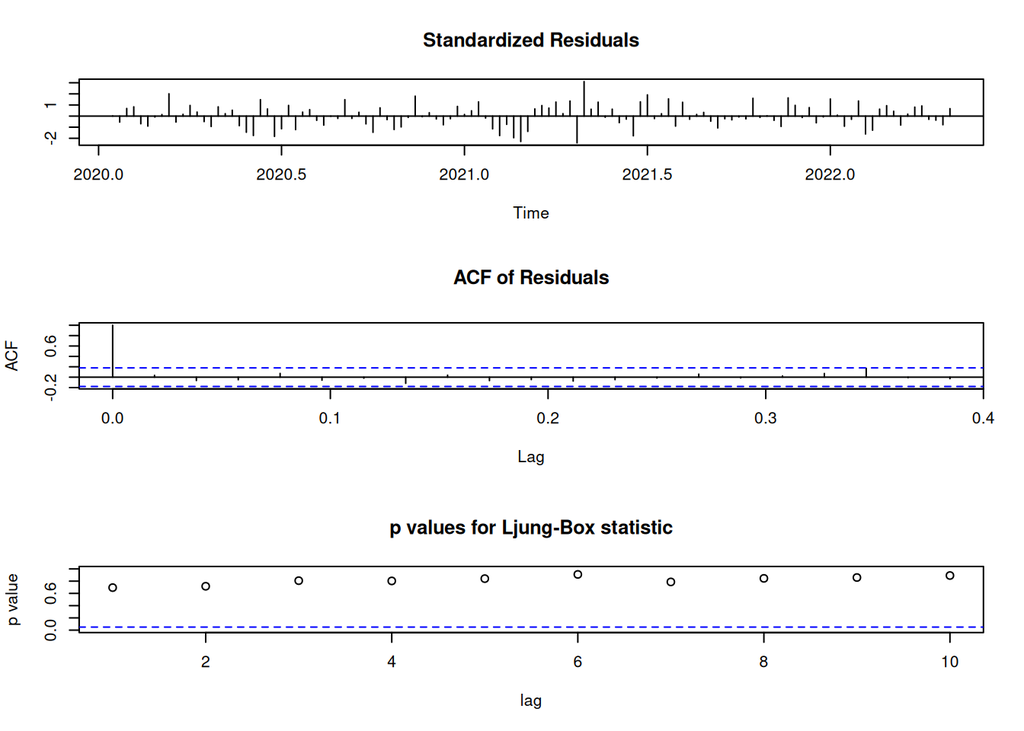

```r
tsdiag(mod1)
```

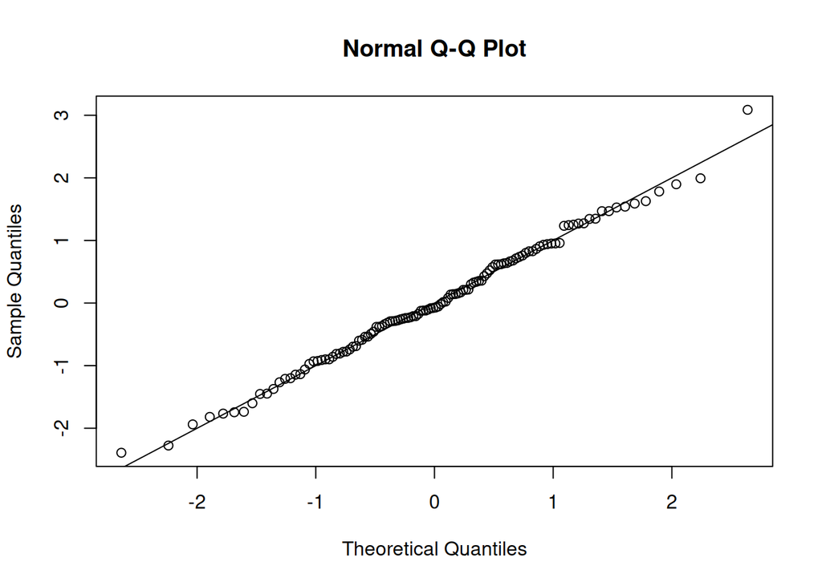

```r
#Gráfica qqplot de los residuales del modelo 1
qqnorm(mod1$resid)
abline(a=0,b=1)
```

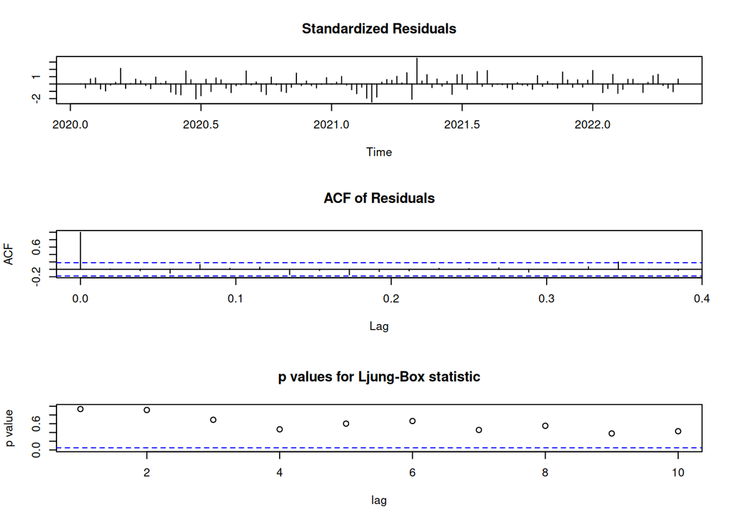

```r
# Para el modelo 2
tsdiag(mod2)
```

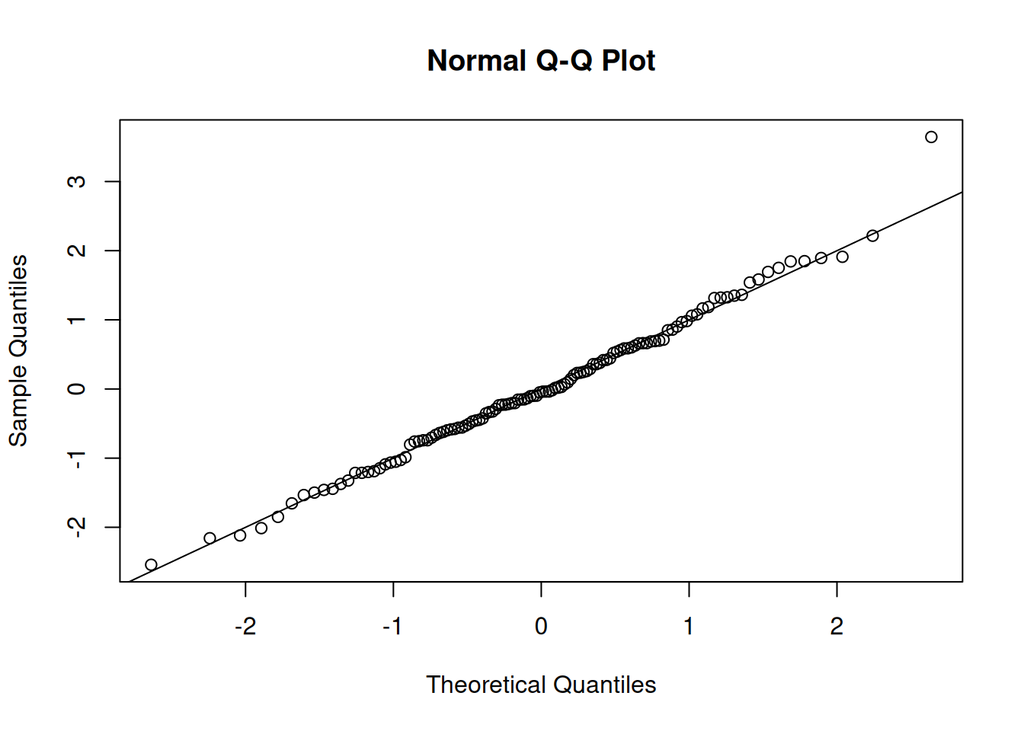

```r
qqnorm(mod2$resid)
abline(a=0,b=1)
```

Haciendo pronósticos con el modelo estimado

```r
pron1 <- predict(mod1,n.ahead = 12)
pron1
```

```
$pred
Time Series:
Start = c(2022, 19)
End = c(2022, 30)
Frequency = 52
 [1] 16.05671 16.40928 16.50297 16.32213 16.05270 15.92379 16.02564 16.25434 16.41544 16.38824 16.21409 16.04669

$se
Time Series:
Start = c(2022, 19)
End = c(2022, 30)
Frequency = 52
 [1] 0.9936002 1.6133586 2.0646103 2.4489185 2.8430614 3.2654087 3.6773496 4.0299156 4.3102502 4.5436417 4.7676635
[12] 5.0083769
```

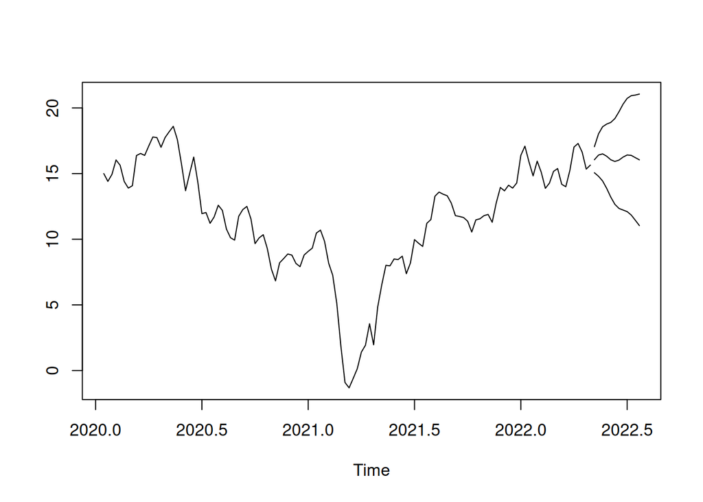

```r
par(mfrow=c(1,1))
ts.plot(kleenex, pron1$pred, pron1$pred - pron1$se, pron1$pred + pron1$se)
```

```r
# Prueba de Dickey-Fuller
# Para revisar si la serie es estacionaria (también se conoce como prueba de raíz unitaria) # H0: la serie no es estacionaria vs Ha: estacionaria
library(tseries)
adf.test(kleenex, k = 0) # k es el número de componentes incluídas en la ecuación de regresión que se prueba
```

```
    Augmented Dickey-Fuller Test

data:  kleenex
Dickey-Fuller = -1.2632, Lag order = 0, p-value = 0.8826
alternative hypothesis: stationary
```

### Ejemplo 2: IPC

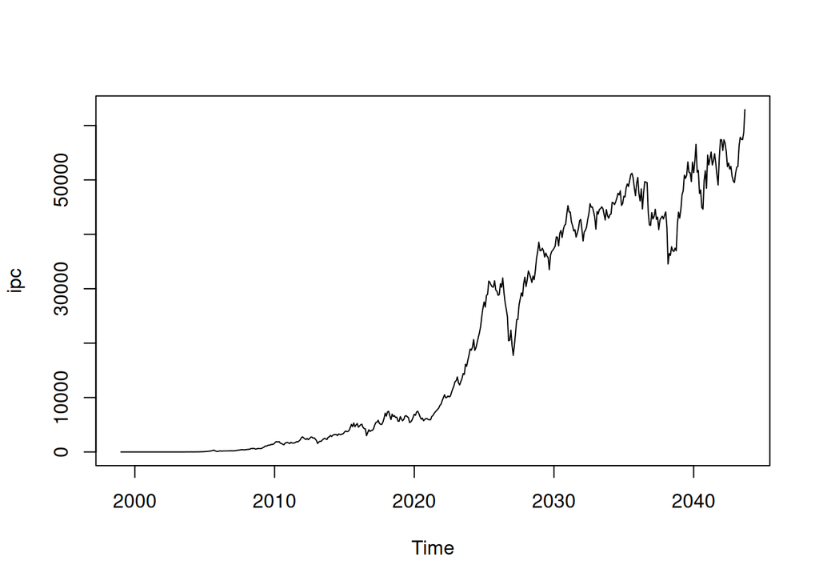

```r
idSeries <- c("SF4782") # identificador de la serie de precios y cotizaciones
ipc <- getSeriesData(idSeries, "1999-01-01")
ipc <- ts(ipc$SF4782$value, start = c(1999,01), freq = 12)
plot(ipc)
```

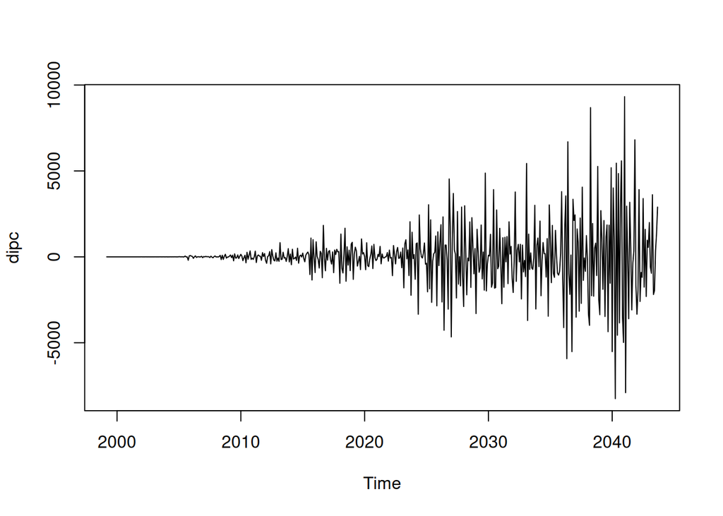

```r
dipc <- diff(ipc,dif = 2)
plot(dipc)
```

Calculemos algunas estadísticas para la serie diferenciada, para verificar si es ruido blanco. Tomemos $h=30$:

```r
#Box-Pierce
Box.test(dipc, lag = 30, type = "Box-Pierce")
```

```
    Box-Pierce test

data:  dipc
X-squared = 200.49, df = 30, p-value < 2.2e-16
```

```r
#Ljung-Box
Box.test(dipc,lag = 30, type = "Ljung-Box")
```

```
    Box-Ljung test

data:  dipc
X-squared = 203.53, df = 30, p-value < 2.2e-16
```

```r
(mod1 <- arima(dipc,order = c(3,1,2))) # Ejemplo de un modelo ajustado
```

```
Call:
arima(x = dipc, order = c(3, 1, 2))

Coefficients:
          ar1      ar2     ar3      ma1     ma2
      -0.0344  -0.0146  0.0600  -1.9869  0.9874
s.e.   0.0443   0.0443  0.0441   0.0084  0.0084

sigma^2 estimated as 1539627:  log likelihood = -4569.17,  aic = 9150.33
```

```r
# Prueba de Dickey Fuller para revisar si la serie es estacionaria (también se conocen como pruebas de
# raíz unitaria)
library(tseries)  # aqui está la función.
adf.test(dipc, k = 0) # k es el número de componentes incluídos en la ecuación de regresión que se prueba
```

```
    Augmented Dickey-Fuller Test

data:  dipc
Dickey-Fuller = -40.387, Lag order = 0, p-value = 0.01
alternative hypothesis: stationary
```

La prueba de Dicker-Fuller consiste en estimar la regresión:
$$\nabla y_t = \phi y\_{t-1}
+\beta_1\nabla y_{t-1} + \beta_2 \nabla y_{t-2} + \cdots + \beta_p\nabla y_{t-p} + u_t$$
donde $u_t$ es un componente de error que se supone tiene media 0.

## Modelos más complicados

Para el modelo ardl, se puede consultar un ejemplo en: https://rpubs.com/cyobero/ardl